# Trabajo Individual: Teoría de la Decisión - Soluciones

Author

Adrián Avelino Martín

# Introducción y Carga de Funciones

En este documento se presenta la resolución completa de los dos problemas de decisión bajo Incertidumbre propuestos.

```r
source("teoriadecision_funciones_incertidumbre.R")
library(knitr)
```

# Problema 1: Matriz de Decisión

Definimos la matriz de decisión del **Problema 1**:

```r
vec_p1 = c(10, 15, 7,
            4, 20, 12,
            8,  8, 18,
           12,  6, 14)

tb01 = crea.tablaX(vec_p1,
                   numalternativas = 4,
                   numestados = 3,
                   nb_alternativas = c("d1", "d2", "d3", "d4"),
                   nb_estados = c("e1", "e2", "e3"))

kable(tb01, caption = "Matriz de Decisiones - Problema 1")
```

Matriz de Decisiones - Problema 1

|  | e1 | e2 | e3 |
| --- | --- | --- | --- |
| d1 | 10 | 15 | 7 |
| d2 | 4 | 20 | 12 |
| d3 | 8 | 8 | 18 |
| d4 | 12 | 6 | 14 |

## Resolución en Situación Favorable (Beneficios)

A continuación resolvemos el problema mediante las funciones individuales del script para situación favorable:

```r
# 1. Criterio Pesimista (Wald)
res_wald_fav <- criterio.Wald(tb01, favorable = TRUE)
res_wald_fav
```

```
$criterio
[1] "Wald"

$metodo
[1] "favorable"

$tablaX
   e1 e2 e3
d1 10 15  7
d2  4 20 12
d3  8  8 18
d4 12  6 14

$ValorAlternativas
d1 d2 d3 d4
 7  4  8  6

$ValorOptimo
[1] 8

$AlternativaOptima
d3
 3
```

```r
# 2. Criterio Optimista
res_opt_fav <- criterio.Optimista(tb01, favorable = TRUE)
res_opt_fav
```

```
$criterio
[1] "Optimista"

$metodo
[1] "favorable"

$tablaX
   e1 e2 e3
d1 10 15  7
d2  4 20 12
d3  8  8 18
d4 12  6 14

$ValorAlternativas
d1 d2 d3 d4
15 20 18 14

$ValorOptimo
[1] 20

$AlternativaOptima
d2
 2
```

```r
# 3. Criterio de Hurwicz (alfa = 0.4)
res_hurwicz_fav <- criterio.Hurwicz(tb01, alfa = 0.4, favorable = TRUE)
res_hurwicz_fav
```

```
$criterio
[1] "Hurwicz"

$alfa
[1] 0.4

$metodo
[1] "favorable"

$tablaX
   e1 e2 e3
d1 10 15  7
d2  4 20 12
d3  8  8 18
d4 12  6 14

$ValorAlternativas
  d1   d2   d3   d4
10.2 10.4 12.0  9.2

$ValorOptimo
[1] 12

$AlternativaOptima
d3
 3
```

```r
# 4. Criterio de Savage
res_savage_fav <- criterio.Savage(tb01, favorable = TRUE)
res_savage_fav
```

```
$criterio
[1] "Savage"

$metodo
[1] "favorable"

$tablaX
   e1 e2 e3
d1 10 15  7
d2  4 20 12
d3  8  8 18
d4 12  6 14

$Mejores
e1 e2 e3
12 20 18

$Pesos
   e1 e2 e3
d1  2  5 11
d2  8  0  6
d3  4 12  0
d4  0 14  4

$ValorAlternativas
d1 d2 d3 d4
11  8 12 14

$ValorOptimo
[1] 8

$AlternativaOptima
d2
 2
```

```r
# 5. Criterio de Laplace
res_laplace_fav <- criterio.Laplace(tb01, favorable = TRUE)
res_laplace_fav
```

```
$criterio
[1] "Laplace"

$metodo
[1] "favorable"

$tablaX
   e1 e2 e3
d1 10 15  7
d2  4 20 12
d3  8  8 18
d4 12  6 14

$ValorAlternativas
      d1       d2       d3       d4
10.66667 12.00000 11.33333 10.66667

$ValorOptimo
[1] 12

$AlternativaOptima
d2
 2
```

```r
# 6. Criterio del Punto Ideal
res_pi_fav <- criterio.PuntoIdeal(tb01, favorable = TRUE)
res_pi_fav
```

```
$criterio
[1] "Punto Ideal"

$metodo
[1] "favorable"

$tablaX
   e1 e2 e3
d1 10 15  7
d2  4 20 12
d3  8  8 18
d4 12  6 14

$Mejores
e1 e2 e3
12 20 18

$ValorAlternativas
      d1       d2       d3       d4
12.24745 10.00000 12.64911 14.56022

$ValorOptimo
[1] 10

$AlternativaOptima
d2
 2
```

### Análisis de Intervalos del Criterio de Hurwicz (Favorable)

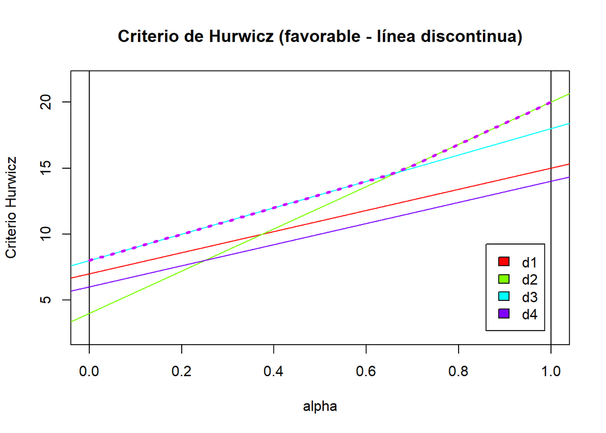

```r
# Representación gráfica y líneas de decisión
dibuja.criterio.Hurwicz(tb01, favorable = TRUE)
```

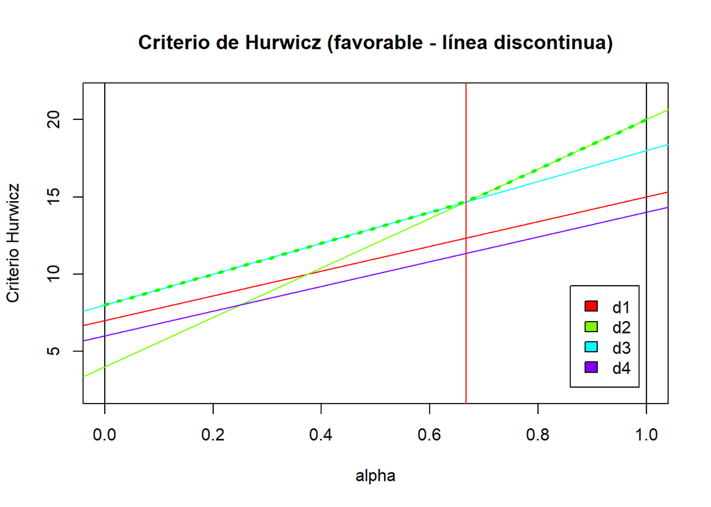

```
$AltOptimas
[1] 3 2

$PuntosDeCorte
[1] 0.667

$IntervalosAlfa
     Intervalo       Alternativa
[1,] "( 0 , 0.667 )" "3"
[2,] "( 0.667 , 1 )" "2"
```

```r
# Obtención de los puntos de intersección
dibuja.criterio.Hurwicz_Intervalos(tb01, favorable = TRUE)
```

## Resolución en Situación Desfavorable (Costes)

Ahora realizamos la resolución considerando que los valores representan costes (caso desfavorable):

```r
# 1. Criterio Pesimista (Wald / Minimax)
res_wald_des <- criterio.Wald(tb01, favorable = FALSE)
res_wald_des
```

```
$criterio
[1] "Wald"

$metodo
[1] "desfavorable"

$tablaX
   e1 e2 e3
d1 10 15  7
d2  4 20 12
d3  8  8 18
d4 12  6 14

$ValorAlternativas
d1 d2 d3 d4
15 20 18 14

$ValorOptimo
[1] 14

$AlternativaOptima
d4
 4
```

```r
# 2. Criterio Optimista
res_opt_des <- criterio.Optimista(tb01, favorable = FALSE)
res_opt_des
```

```
$criterio
[1] "Optimista"

$metodo
[1] "desfavorable"

$tablaX
   e1 e2 e3
d1 10 15  7
d2  4 20 12
d3  8  8 18
d4 12  6 14

$ValorAlternativas
d1 d2 d3 d4
 7  4  8  6

$ValorOptimo
[1] 4

$AlternativaOptima
d2
 2
```

```r
# 3. Criterio de Hurwicz (alfa = 0.4)
res_hurwicz_des <- criterio.Hurwicz(tb01, alfa = 0.4, favorable = FALSE)
res_hurwicz_des
```

```
$criterio
[1] "Hurwicz"

$alfa
[1] 0.4

$metodo
[1] "desfavorable"

$tablaX
   e1 e2 e3
d1 10 15  7
d2  4 20 12
d3  8  8 18
d4 12  6 14

$ValorAlternativas
  d1   d2   d3   d4
11.8 13.6 14.0 10.8

$ValorOptimo
[1] 10.8

$AlternativaOptima
d4
 4
```

```r
# 4. Criterio de Savage
res_savage_des <- criterio.Savage(tb01, favorable = FALSE)
res_savage_des
```

```
$criterio
[1] "Savage"

$metodo
[1] "desfavorable"

$tablaX
   e1 e2 e3
d1 10 15  7
d2  4 20 12
d3  8  8 18
d4 12  6 14

$Mejores
e1 e2 e3
 4  6  7

$Pesos
   e1 e2 e3
d1  6  9  0
d2  0 14  5
d3  4  2 11
d4  8  0  7

$ValorAlternativas
d1 d2 d3 d4
 9 14 11  8

$ValorOptimo
[1] 8

$AlternativaOptima
d4
 4
```

```r
# 5. Criterio de Laplace
res_laplace_des <- criterio.Laplace(tb01, favorable = FALSE)
res_laplace_des
```

```
$criterio
[1] "Laplace"

$metodo
[1] "desfavorable"

$tablaX
   e1 e2 e3
d1 10 15  7
d2  4 20 12
d3  8  8 18
d4 12  6 14

$ValorAlternativas
      d1       d2       d3       d4
10.66667 12.00000 11.33333 10.66667

$ValorOptimo
[1] 10.66667

$AlternativaOptima
d1 d4
 1  4
```

```r
# 6. Criterio del Punto Ideal
res_pi_des <- criterio.PuntoIdeal(tb01, favorable = FALSE)
res_pi_des
```

```
$criterio
[1] "Punto Ideal"

$metodo
[1] "desfavorable"

$tablaX
   e1 e2 e3
d1 10 15  7
d2  4 20 12
d3  8  8 18
d4 12  6 14

$Mejores
e1 e2 e3
 4  6  7

$ValorAlternativas
      d1       d2       d3       d4
10.81665 14.86607 11.87434 10.63015

$ValorOptimo
[1] 10.63015

$AlternativaOptima
d4
 4
```

### Análisis de Intervalos del Criterio de Hurwicz (Desfavorable)

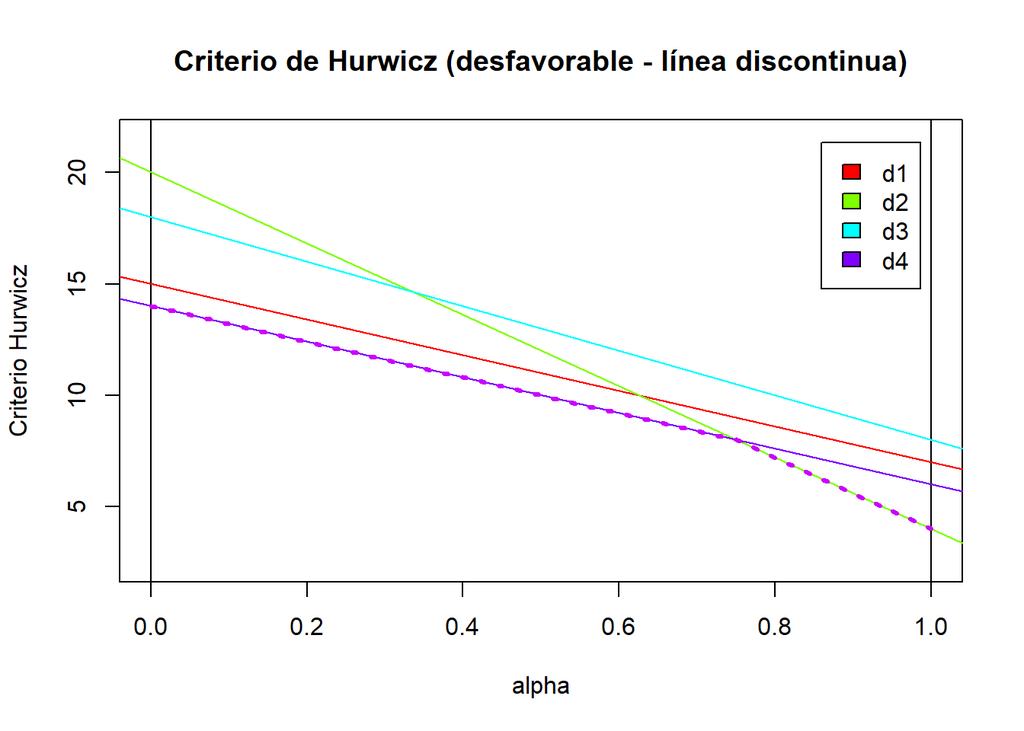

```r
# Representación gráfica y líneas de decisión
dibuja.criterio.Hurwicz(tb01, favorable = FALSE)
```

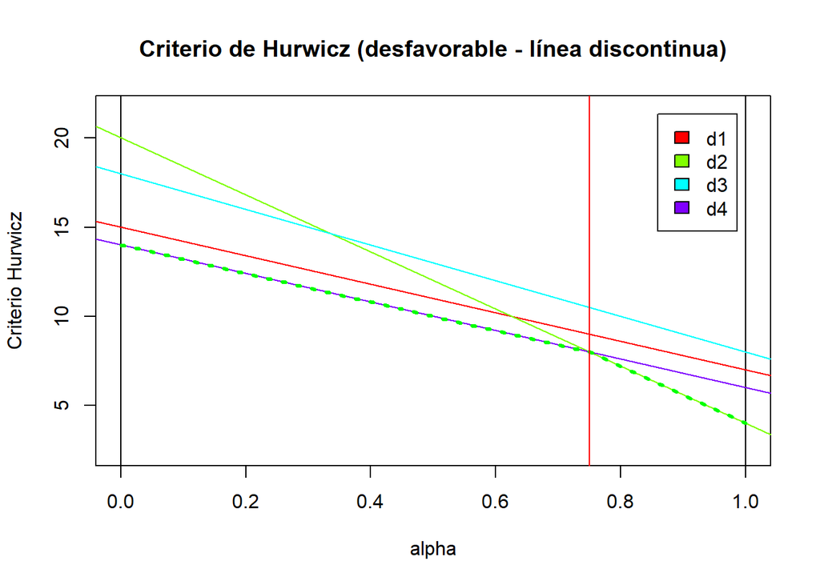

```
$AltOptimas
[1] 4 2

$PuntosDeCorte
[1] 0.75

$IntervalosAlfa
     Intervalo      Alternativa
[1,] "( 0 , 0.75 )" "4"
[2,] "( 0.75 , 1 )" "2"
```

```r
# Obtención de los puntos de intersección
dibuja.criterio.Hurwicz_Intervalos(tb01, favorable = FALSE)
```

## Justificación y Solución del Cuestionario 1

1. **Pregunta 1:** *En situación favorable (beneficios), bajo el criterio Pesimista (Wald) la alternativa óptima es $d_3$ con un valor óptimo de 8.*
   - **Verdadero.** En beneficio, los mínimos por fila son: $d_1=7, d_2=4, d_3=8, d_4=6$. El valor máximo de estos peores resultados es $8$, correspondiente a la alternativa $d_3$.
2. **Pregunta 2:** *En situación favorable, el criterio de Savage selecciona la alternativa $d_3$ como la mejor decisión.*
   - **Falso.** La matriz de arrepentimiento presenta pérdidas máximas de oportunidad por fila de: $d_1: 11, d_2: 8, d_3: 12, d_4: 14$. El menor arrepentimiento máximo es $8$, correspondiente a $d_2$.
3. **Pregunta 3:** *En situación desfavorable (costes), el criterio de Wald (Minimax) determina que la alternativa óptima es $d_4$ con un coste máximo garantizado de 14.*
   - **Verdadero.** En costes, los costes máximos por fila son: $d_1=15, d_2=20, d_3=18, d_4=14$. El menor coste máximo es $14$, alcanzado con $d_4$.
4. **Pregunta 4:** *En situación desfavorable, el criterio de Hurwicz con factor de pesimismo $\alpha=0.4$ asigna el menor coste ponderado a la alternativa $d_2$.*
   - **Falso.** Los costes ponderados con $\alpha=0.4$ son: $d_1=11.8$, $d_2=13.6$, $d_3=14.0$, $d_4=10.8$. El menor coste ponderado se obtiene con $d_4$, no con $d_2$.
5. **Pregunta 5:** *El criterio de Laplace selecciona la misma alternativa óptima ($d_2$) tanto si el problema se plantea como de beneficios como si se plantea como de costes.*
   - **Falso.** Las medias por alternativa son: $d_1=10.67$, $d_2=12.00$, $d_3=11.33$, $d_4=10.67$. En beneficios se elige el máximo ($d_2$), mientras que en costes se eligen las de menor coste medio ($d_1$ y $d_4$).

### Respuestas Verdaderas Problema 1

- **Pregunta 1:** V
- **Pregunta 2:** F
- **Pregunta 3:** V
- **Pregunta 4:** F
- **Pregunta 5:** F

# Problema 2: Aplicación en Entorno Real (“AgroTech Soluciones”)

Creamos la matriz de rendimientos económicos netos (favorable) para la empresa “AgroTech Soluciones”:

```r
vec_p2 = c(25, 20,  15,
           50, 35,  10,
           90, 40, -15,
           35, 30,  25,
           70, 45,  20)

tb02 = crea.tablaX(vec_p2,
                   numalternativas = 5,
                   numestados = 3,
                   nb_alternativas = c("Riego Inteligente", "Bioplaguicidas", "Software Predictivo", "Baterías                      BEES", "Proyecto Híbrido"),
                   nb_estados = c("Favorable", "Normal", "Adverso"))

kable(tb02, caption = "Matriz de Rendimientos Económicos Netos - AgroTech Soluciones")
```

Matriz de Rendimientos Económicos Netos - AgroTech Soluciones

|  | Favorable | Normal | Adverso |
| --- | --- | --- | --- |
| Riego Inteligente | 25 | 20 | 15 |
| Bioplaguicidas | 50 | 35 | 10 |
| Software Predictivo | 90 | 40 | -15 |
| Baterías BEES | 35 | 30 | 25 |
| Proyecto Híbrido | 70 | 45 | 20 |

## Resolución con `criterio.Todos()`

```r
res_p2_todos <- criterio.Todos(tb02, alfa = 0.4, favorable = TRUE)
kable(t(res_p2_todos), caption = "Resolución Global mediante criterio.Todos (alfa = 0.4)")
```

Resolución Global mediante criterio.Todos (alfa = 0.4)

|  | Riego Inteligente | Bioplaguicidas | Software Predictivo | Baterías BEES | Proyecto Híbrido | iAlt.Opt (fav.) |
| --- | --- | --- | --- | --- | --- | --- |
| Favorable | 25 | 50 | 90 | 35 | 70 | – |
| Normal | 20 | 35 | 40 | 30 | 45 | – |
| Adverso | 15 | 10 | -15 | 25 | 20 | – |
| Wald | 15 | 10 | -15 | 25 | 20 | Baterías BEES |
| Optimista | 25 | 50 | 90 | 35 | 70 | Software Predictivo |
| Hurwicz | 19 | 26 | 27 | 29 | 40 | Proyecto Híbrido |
| Savage | 65 | 40 | 40 | 55 | 20 | Proyecto Híbrido |
| Laplace | 20.00 | 31.67 | 38.33 | 30.00 | 45.00 | Proyecto Híbrido |
| Punto Ideal | 70.36 | 43.87 | 40.31 | 57.01 | 20.62 | Proyecto Híbrido |
| Veces Optima | 0 | 0 | 1 | 1 | 4 | Proyecto Híbrido |

### Análisis de Intervalos del Criterio de Hurwicz (Problema 2)

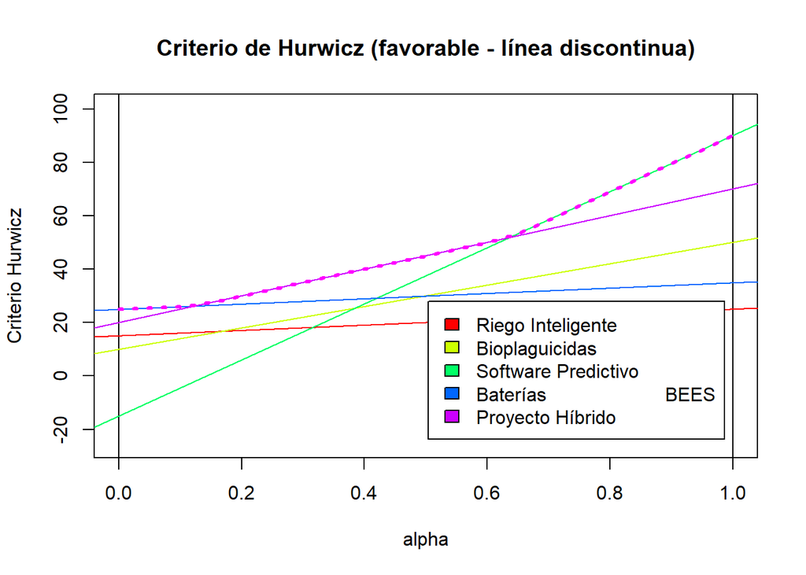

```r
# Representación gráfica y líneas de decisión
dibuja.criterio.Hurwicz(tb02, favorable = TRUE)
```

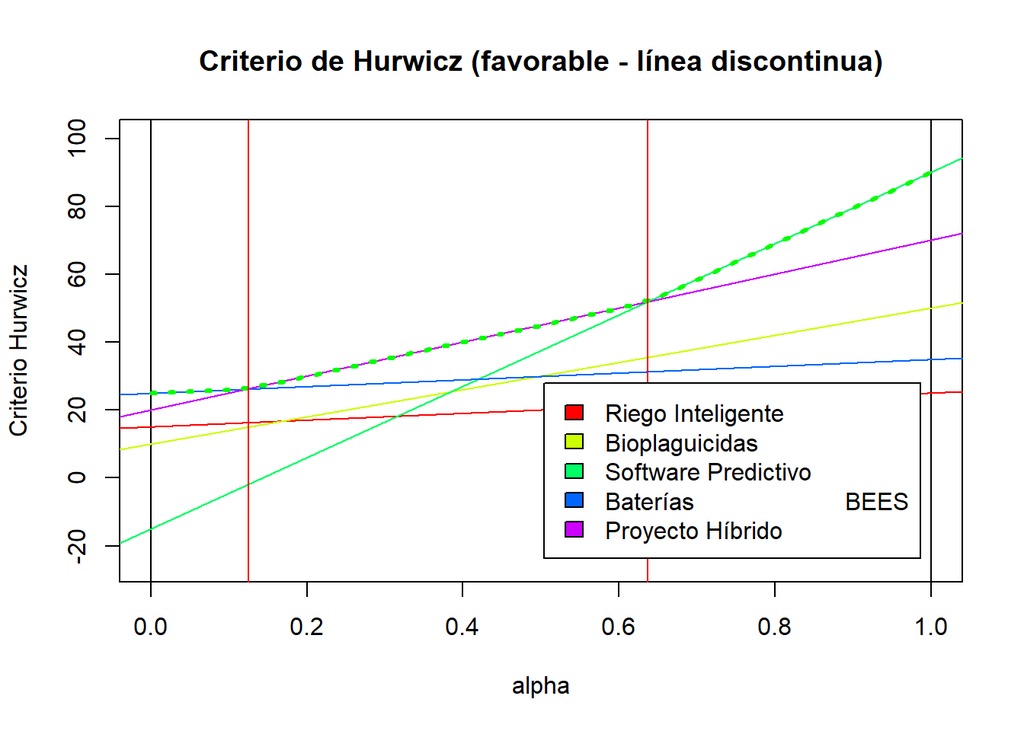

```
$AltOptimas
[1] 4 5 3

$PuntosDeCorte
[1] 0.125 0.636

$IntervalosAlfa
           Intervalo           Alternativa
Soluciones "( 0 , 0.125 )"     "4"
           "( 0.125 , 0.636 )" "5"
           "( 0.636 , 1 )"     "3"
```

```r
# Obtención de los puntos de intersección
dibuja.criterio.Hurwicz_Intervalos(tb02, favorable = TRUE)
```

### Respuestas Verdaderas Problema 2

- **Pregunta 1:** V
- **Pregunta 2:** F
- **Pregunta 3:** V
- **Pregunta 4:** V
- **Pregunta 5:** F